# Lesson 3: Workflow and Statistical Test in R

Anna Josephson

2025-06-05

# Learning Objectives

1. Streamline workflow using R Projects and Git
2. Read and write data using files
3. Gain comfort with `tidyverse`
4. Run standard statistical tests:
   - Student’s t
   - ANOVA
   - Simple linear regression
5. Gain literacy with piping (`%>%`) and tidy tools.

R was designed for statistical analyses.  
This lesson provides an overview of reading data, writing output, and running standard statistical tests in R.  
These include:

- t-tests
- linear regression
- analysis of variance.

## 1. Streamline Workflow

To help streamline our workflow, we are going to:

1. Use an `.Rproj`
2. Create directories within the project
3. Update our `.gitignore` file to ignore data
4. Place the data into the R project.

### Step-by-step instructions:

1. Open RStudio and use the RStudio dropdown menu to create a new R Project in your existing git folder
2. Use the code below to create subfolders in the R project to hold `data` and `output`:

```r
dir.create(path = "data")
dir.create(path = "output")
```

`dir.create()` creates a new folder (directory). Useful for organizing your project (e.g., folders for data or outputs).

These folders will help keep raw data separate from results.

3. Open your `.gitignore` file in RStudio:
- Navigate via the Files pane, or use the dropdown menu (`File > Open File...`).
- Add the following line to ignore parquet files (under the section `# Session Data Files`):

```
*.parquet
```

Save the file. This prevents Git from tracking large raw data files.

4. Copy the data file (`merged_data.parquet`) into the `data/` folder.

Then, verify that Git is ignoring it: - Open **GitHub Desktop**. - You should **not** see the `.parquet` file listed in the changes.

## 2. Read and write data using files

Use the code Anna shared in Lesson 1 to create subfolders in the Rproj to hold data and output.

Now let’s begin working with the data in a new R script.

Start a New Script:

1. In RStudio, go to `File > New File > R Script`
2. Save it as `mobility-tests.R` **within your Git project folder**.

We always begin with package loading:

```r
library(arrow)      # for reading parquet files
library(tidyverse)  # for data manipulation and visualization
```

- `arrow` A package that allows R to read and write data in Parquet format, which is a fast and compact way to store data.
- `tidyverse` A collection of packages (including dplyr, ggplot2, readr, and more) that work together and follow the same design philosophy for working with data.

Load the Dataset:

Read in the data using the `arrow` package:

```r
merged_data <- read_parquet(file = "merged_data.parquet", stringsAsFactors = TRUE)
```

The function `read_parquet()` takes at least two arguments:

1. The file path to the dataset
2. How to handle text strings (`stringsAsFactors = TRUE` means treat text as categorical data)

The data from the file is now stored in an object called `merged_data`.

Initial Exploration with Visualization:

A simple yet powerful way to begin understanding data is to **visualize** it. Let’s start with a boxplot of upward mobility by state:

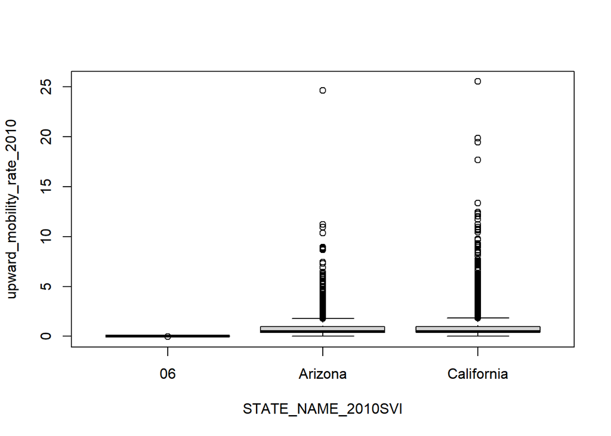

```r
boxplot(formula = upward_mobility_rate_2010 ~ STATE_NAME_2010SVI, data = merged_data)
```

Identify and Handle Anomalies:

While exploring data, we might notice anomalies. For instance, a state named `06` might appear — this likely isn’t a valid state name.

Let’s remove such entries:

```r
merged_data <- merged_data[!(merged_data$STATE_NAME_2010SVI %in% "06"), ]
```

Re-plot the boxplot to confirm the issue is resolved:

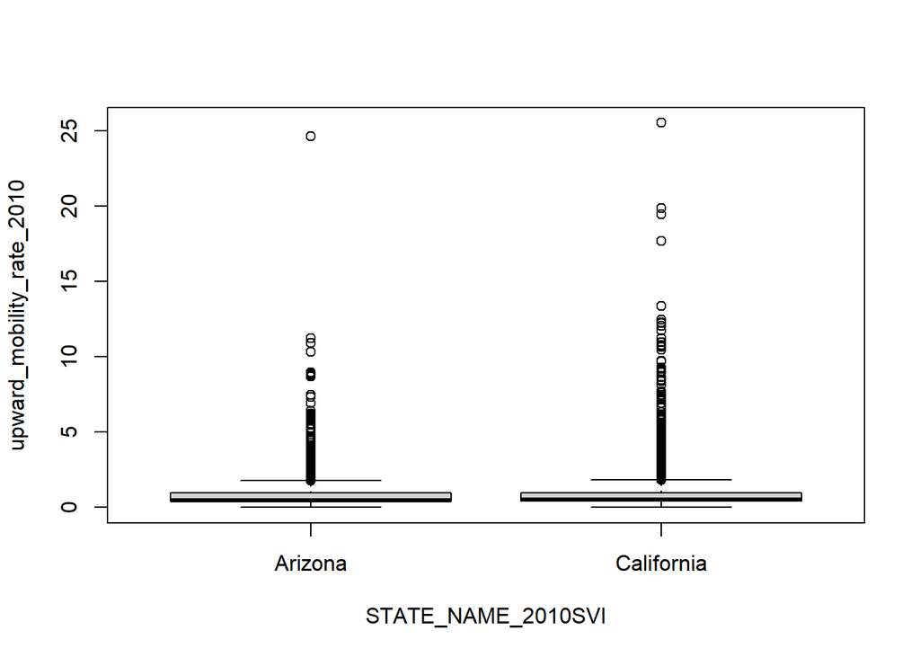

```r
boxplot(formula = upward_mobility_rate_2010 ~ STATE_NAME_2010SVI, data = merged_data)
```

Let’s create another boxplot to explore total population by state:

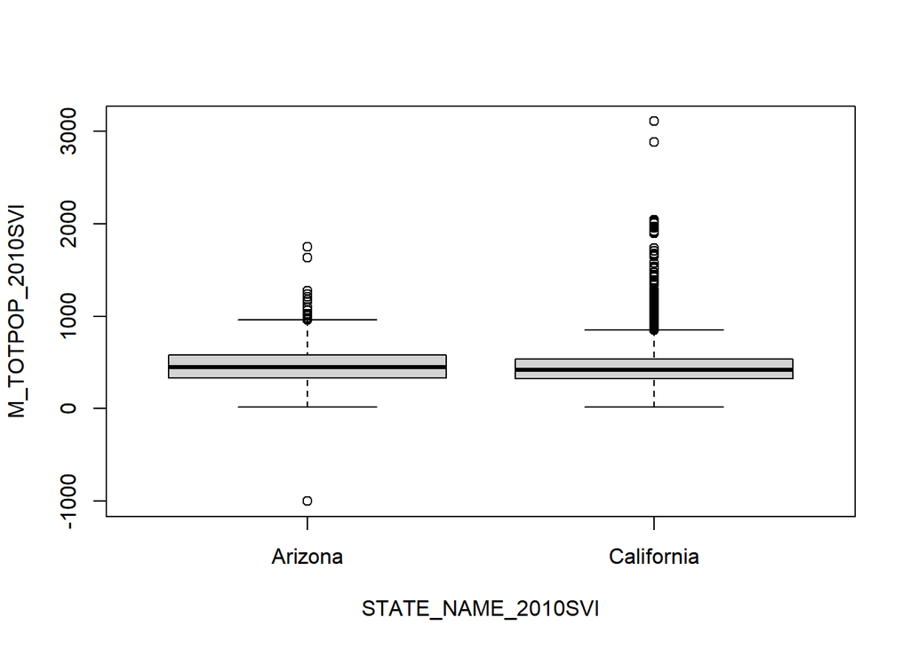

```r
boxplot(formula = M_TOTPOP_2010SVI ~ STATE_NAME_2010SVI, data = merged_data)
```

Take a moment: What does this new plot tell you? Why did you choose this variable to explore next? Are there patterns worth investigating further?

Now tips on Boxplots

- Boxplot uses the formula syntax: `y ~ group`
- The left of the `~` is plotted on the y-axis
- The right is the grouping variable on the x-axis.

If you’re curious, type `?boxplot` in the Console for more information.

## 3. Introduction to tidyverse and Advanced Data Handling

### 3.1 Case Sensitivity in R

R is **case-sensitive**, which means that `State`, `STATE`, and `state` are treated as different objects. If you refer to an object with the wrong case, R will throw an error. For example:

```r
boxplot(formula = M_TOTPOP_2010SVI ~ state_NAME_2010SVI, data = merged_data)
```

This won’t run because `state_NAME_2010SVI` doesn’t exist (the correct variable is `STATE_NAME_2010SVI`).

> **Tip**: Decide with your team or advisor on a consistent naming style (e.g., all lower case) to avoid such issues.

### 3.2 Installing and Loading tidyverse

The `tidyverse` is a powerful collection of R packages that simplify data manipulation and visualization. To install it:

```r
install.packages("tidyverse")
```

Then, load it in your script:

```r
library(tidyverse)
```

### 3.3 Using tidyverse for Summarizing Data

Let’s calculate the mean upward mobility for California and Arizona.

#### **Traditional (Base R) Method**:

```r
#1. First, create two new datasets by filtering the rows based on the state abbreviation.

subset_data_ca <- subset(merged_data, STATE_ABBR_2010SVI == "CA")
subset_data_az <- subset(merged_data, STATE_ABBR_2010SVI == "AZ")


#2.Calculate the average upward mobility rate in 2010 for each state using the mean() function.

print(upward_mean_2010_ca <- mean(subset_data_ca$upward_mobility_rate_2010))
```

```
## [1] 0.9007544
```

```r
print(upward_mean_2010_az <- mean(subset_data_az$upward_mobility_rate_2010))
```

```
## [1] 0.9555026
```

```r
#3. Once we have both means, we store them in a new data frame so they’re easier to use later.
upward_mobility_means_2010 <- data.frame(State = c("CA", "AZ"),
                         up_2010_mean = c(upward_mean_2010_ca, upward_mean_2010_az))

# This process works, but it’s long and repetitive. Imagine doing this for all 50 states!
# Let’s use tidyverse to make this more efficient.
```

The `subset()` function is part of base R, meaning you don’t need any additional packages to use it. Its main purpose is to extract a portion of a data frame based on a logical condition.

The `mean ()` (or average) is a measure of central tendency, it gives us a single value that summarizes the center point of a dataset.

The `data.frame()` is used to create a new data frame by combining vectors (columns) of data.

#### **Tidyverse Method (Concise and Scalable)**:

We use the pipe symbol (%>%) to send our dataset (`merged_data`) through a sequence of commands.

```r
# Group the full dataset by state abbreviation, then calculate the mean upward mobility rate for each group.

state_group <- merged_data %>%
  group_by(STATE_ABBR_2010SVI)

state_mob_means <- state_group %>%
  summarise(up_mean = mean(upward_mobility_rate_2010, na.rm = TRUE))

# Often, there are missing values (NA) that we don't want in our results.
# Let’s remove any rows where the state abbreviation is missing.

state_mob_means <- state_mob_means %>%
  filter(!is.na(STATE_ABBR_2010SVI))

#This is much faster and cleaner than calculating each state manually. Now state_mob_means is the same as upward_mobility_means_2010
```

`group_by()` splits your data into groups (like by state or county).

`summarize()` then applies functions like mean() or sd() to each group.

So let’s talk about what is a pipe operator.

### 3.4 The Pipe Operator `%>%`

The pipe operator `%>%` sends the result from the left-hand side to the first argument of the function on the right-hand side. It makes the code more readable and helps us chain multiple commands together.

Meaning: so this means that `state %>% group_by(STATE_ABBR_2010SVI)` is the same as `group_by(state, STATE_ABBR_2010SVI)`.

The example below does three things:

1. Starts with the full dataset (merged_data)
2. Groups it by state
3. Calculates the mean upward mobility rate.

```r
upward <- merged_data %>%
  group_by(STATE_ABBR_2010SVI) %>%
  summarise(means_2010 = mean(upward_mobility_rate_2010, na.rm = TRUE))
```

4. Removes rows where the state is NA.

```r
upward <- upward %>% filter(!is.na(STATE_ABBR_2010SVI))
```

Let’s review what we did:

- First, we group the data by state (identified by `STATE_ABBR_2010SVI`)
- Then, we calculate the average upward mobility rate for each state using the `mean()` function
- The final result is saved into a new variable called `upward`.

### 3.5 Adding Error Bars with ggplot2

Let’s visualize means and standard error (SE):

```r
upward_stats <- merged_data %>%
  group_by(STATE_ABBR_2010SVI, COUNTY_2010SVI) %>%
  summarise(up_means = mean(upward_mobility_rate_2010, na.rm = TRUE),
            up_se = sd(upward_mobility_rate_2010, na.rm = TRUE)/sqrt(n()))
```

Here, we are grouping by both state and county.

We calculate:

- The mean of upward mobility
- The standard error (SE), which tells us how spread out the data is. It’s calculated by taking the standard deviation divided by the square root of the sample size
- This gives us a more precise picture of variation across counties within each state.

Remember to drop the NA.

```r
upward_stats <- upward_stats %>% filter(!is.na(STATE_ABBR_2010SVI))
```

#### Basic ggplot with Error Bars

Remember that data visualization helps us **tell a story**. Let’s plot the mean upward mobility per state using ggplot2.

`ggplot()` starts a plot.

`aes()`defines the axes and variables to plot.

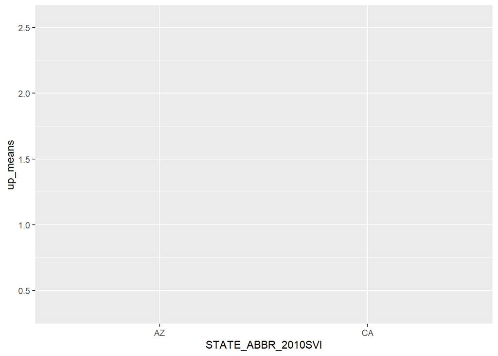

```r
ggplot(data = upward_stats, mapping = aes(x = STATE_ABBR_2010SVI, y = up_means))
```

But, this gives us a blank plot — we haven’t told R what kind of plot to make. Do we want a bar chart? A scatterplot? Maybe a heatmap?

We are using means as points, so we use `geom_point()`. And to add component to our plot we use the sign **+**.

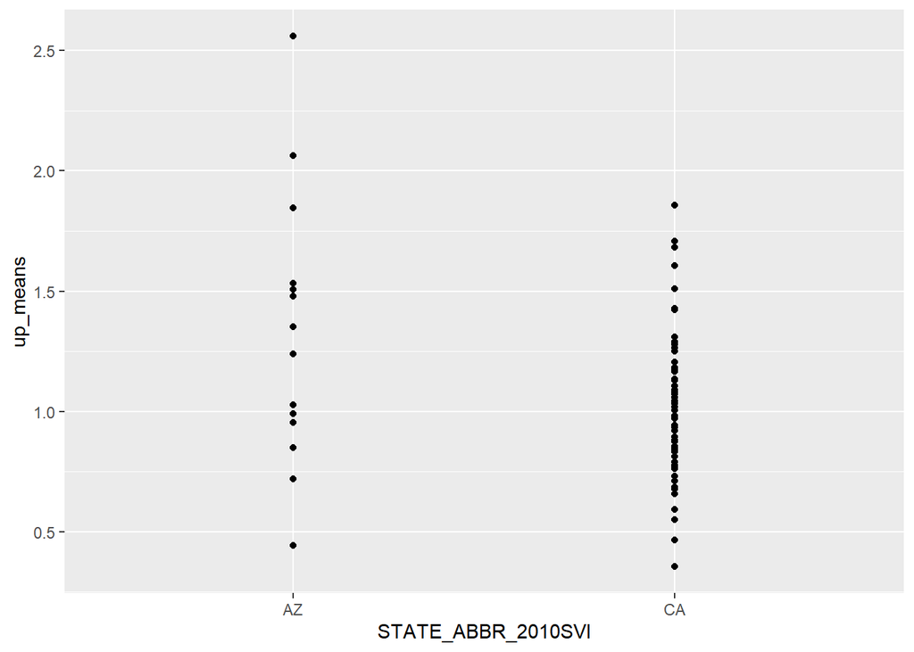

```r
ggplot(data = upward_stats, mapping = aes(x = STATE_ABBR_2010SVI, y = up_means)) +
  geom_point()
```

Let’s add error bars using `geom_errorbar()`.

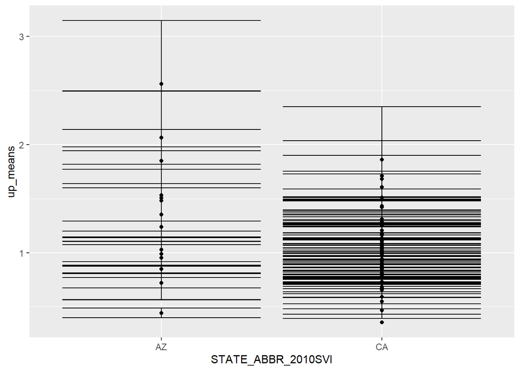

```r
ggplot(data = upward_stats, mapping = aes(x = STATE_ABBR_2010SVI, y = up_means)) +
  geom_point() +
  geom_errorbar(mapping = aes(ymin = up_means - up_se,
                              ymax = up_means + up_se))
```

Tweak the error bars for visibility (make them thinner).

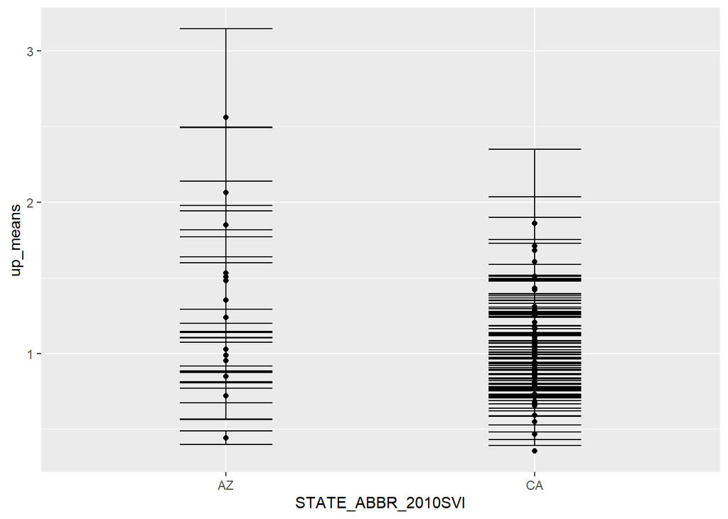

```r
ggplot(data = upward_stats, mapping = aes(x = STATE_ABBR_2010SVI, y = up_means)) +
  geom_point() +
  geom_errorbar(mapping = aes(ymin = up_means - up_se,
                              ymax = up_means + up_se),
                width = 0.30)
```

So,

- We use `ggplot2` to create plots
- `geom_point()` adds dots for the mean upward mobility rates
- `geom_errorbar()` shows how much variability there is around each mean using the SE
- We include `width = 0.30` to make the error bars visually cleaner.

> **Reflection**: Why does this graph look busy? How can we make it more readable?

Because we are plotting many counties, grouped by state, it can get crowded or hard to interpret.

To simplify, we can just summarize at the state level again and replot.

#### Cleaned Up by State

```r
upward_stats_st <- merged_data %>%
  group_by(STATE_ABBR_2010SVI) %>%
  summarize(up_means = mean(upward_mobility_rate_2010),
            up_se = sd(upward_mobility_rate_2010)/sqrt(n()))
```

Remember to drop the NA.

```r
upward_stats_st <- upward_stats_st %>% filter(!is.na(STATE_ABBR_2010SVI))
```

Redo the graph.

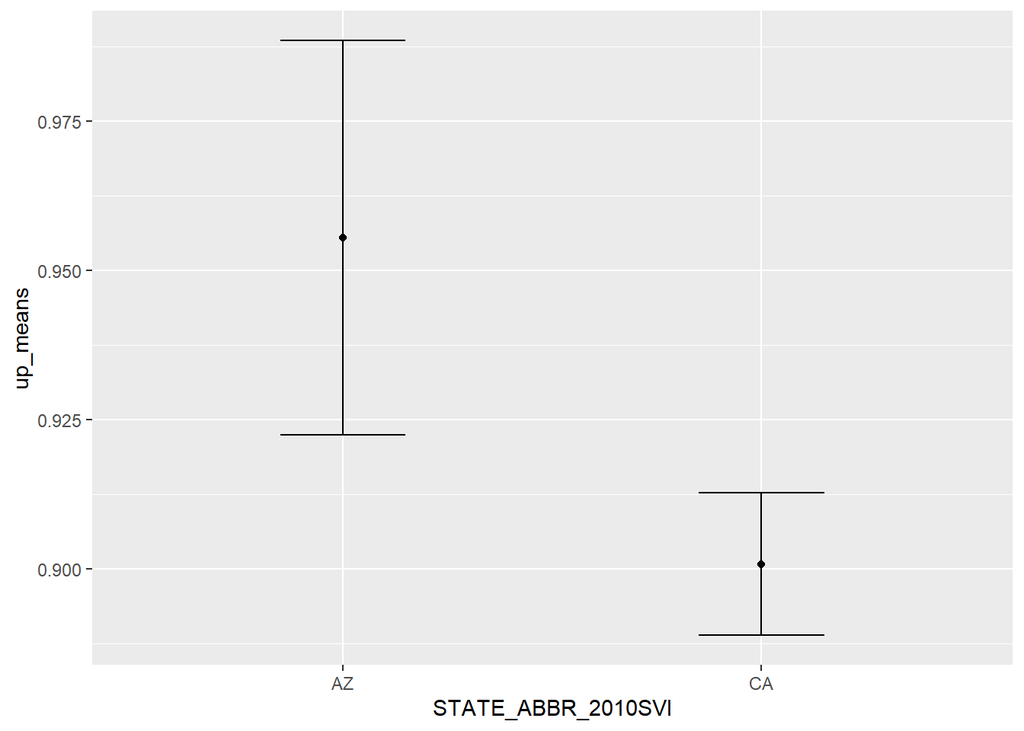

```r
ggplot(data = upward_stats_st, mapping = aes(x = STATE_ABBR_2010SVI, y = up_means)) +
  geom_point() +
  geom_errorbar(mapping = aes(ymin = up_means - up_se,
                              ymax = up_means + up_se),
                width = 0.30)
```

This gives us a much cleaner and easier-to-read visualization.

#### Data and Storytelling

All data originates from human decisions, even if it’s collected automatically (like from sensors or machines). Reflect on:

- What to measure
- When to measure it
- How to structure it.

When working with data, ask yourself:

- Who generated this data?
- What was their purpose?
- What limitations or biases might exist?
- Has the data been reused in different ways?

> **Critical Thinking**: Are we reusing them responsibly?

This is important for being a responsible data analyst.

### 3.6 More tidyverse Tricks

It’s a good habit to create a working copy of your dataset. This way, the original stays untouched and you can experiment safely.

```r
merged <- merged_data
```

Now `merged` is your editable copy, while `merged_data` remains preserved in its original form.

Before diving into statistical tests, let’s quickly explore 10 awesome things you can do easily using the tidyverse in R. You don’t need to master them all right now — but we’ll talk through what each one does and why it’s helpful.

#### **Selecting columns**

`select()` removes columns with underscores and keeps those that start with “upward”— like upward mobility data.

```r
merged %>%
  dplyr:: select(!contains("_"), starts_with ("upward"))
```

```
## # A tibble: 9,598 × 11
##    geo2010   CensusTract Pop2010 POP2010 state county tract geoid `Census Tract`
##    <chr>     <chr>         <dbl>   <dbl> <???>  <???> <???> <???> <chr>
##  1 04001942… 04001942600    1578    1578     .      .     .     . <NA>
##  2 04001942… 04001942700    5628    5628     .      .     .     . <NA>
##  3 04001944… 04001944000    6043    6043     .      .     .     . <NA>
##  4 04001944… 04001944100    5870    5870     .      .     .     . <NA>
##  5 04001944… 04001944201    4010    4010     .      .     .     . <NA>
##  6 04001944… 04001944202    4053    4053     .      .     .     . <NA>
##  7 04001944… 04001944300    6958    6958     .      .     .     . <NA>
##  8 04001944… 04001944901    4021    4021     .      .     .     . <NA>
##  9 04001944… 04001944902    4853    4853     .      .     .     . <NA>
## 10 04001945… 04001945001    4497    4497     .      .     .     . <NA>
## # ℹ 9,588 more rows
## # ℹ 2 more variables: upward_mobility_rate_2010 <dbl>,
## #   upward_mobility_rate_2020 <dbl>
```

#### **Reordering columns**

`relocate()` puts all columns containing “STATE” after the 2020 upward mobility rate column.

```r
merged <- merged %>%
  dplyr:: relocate(contains("STATE"), .after = upward_mobility_rate_2020)
```

#### **Create and Place a Unique Identifier**

Now you’ve got a tidy unique ID column in a clean spot.

```r
unique_id <- merged %>%
  dplyr:: group_by(STATE_FIPS_2010SVI, COUNTY_2010SVI, CENSUSAREA_2010SVI) %>%
  dplyr:: mutate(uniqueid = row_number(), .before = contains("_"))
```

#### **Pivoting (Wide ↔︎ Long)**

Tidyverse makes switching between wide and long formats easy. Here’s the general syntax — though it doesn’t quite apply to our data right now:

```r
#Wide to long
# merged_long <- unique_id %>%
  #tidyr::pivot_longer(contains("_"),
                      #names_to = c("upward"),
                      #names_sep =("_"))


#this is general synthax, but doesn't make sense for what we're doing right now

# Long to wide

# merged_wide <- _merged_long %>%
   #tidyr::pivot_wider(names_from = c("upward),
                      #values_from = "value",
                      #names_sep = "_")


#again, as we didn't change, muted code
```

#### **Summarize Across Multiple Columns**

Compute summary stats across multiple columns:

```r
merged_stats_up <- merged %>%
  dplyr::group_by(STATE_ABBR_2010SVI) %>%
  dplyr::summarize(across(starts_with("upward"),
                          list(~mean(.x, na.rm = TRUE),
                               ~sd(.x, na.rm = TRUE))))
```

#### **Rename Columns When Summarizing**

Get clearer names for your summary columns.

```r
merged_stats_up <- merged %>%
  dplyr::group_by(STATE_ABBR_2010SVI) %>%
  dplyr::summarize(across(starts_with("upward"),
                          list(mean = ~mean(.x, na.rm = TRUE),
                               sd = ~sd(.x, na.rm = TRUE)),
                          .names = "{gsub('_', '', col)}_{fn}"))
```

### 3.7 Advanced: Modeling and Nesting

You can even run models within groups:

```r
upward_models <- merged %>%
  group_by(STATE_ABBR_2010SVI) %>% summarise(model list(lm(upward_mobility_rate_2010 ~ POP2010)))
```

We’ll return to this when we cover regression.

And `nest()` your data:

Turn grouped data into list-columns.

```r
merged <- nest_by(state_group)
```

#### **Plotting Across Subsets**

Tidyverse makes graphing across groups intuitive. We’ll only touch on it today, but check out a ggplot2 workshop if you’re interested!

## 4. Running a Basic Statistical Test: Student’s t-test

We’ve made quite a few changes to `merged_data`, so let’s reset and start fresh.

```r
merged <- merged_data
```

This part is all about starting some basic statistical tests and not just the *how* but also the *why* behind each one. But before we dive in too far: if you haven’t taken a statistics class before, I *highly* recommend it!. It’ll make a lot of this feel more intuitive.

### Statistical Testing: T-Test

What is a t-test? A t-test helps us compare two groups to see if their averages are statistically different.

For example, is the average upward mobility rate in one state significantly different from another?

We use it when we want to know:

“Are these two groups different enough that it’s unlikely this happened by chance?”

We’ll start simple — with a Student’s t-test. Let’s compare upward mobility between Arizona and California.

```r
az <- merged_data[merged_data$STATE_NAME_2010SVI == "Arizona", ]
ca <- merged_data[merged_data$STATE_NAME_2010SVI == "California", ]
```

(Quick story: I once forgot about capitalization and wrote STATE instead of STATE_NAME_2010SVI… it didn’t work and gave me an empty dataset. Always check your column names!).

Okay—what happened here? Let’s break it down:

1. Merged_data is a data.frame (you can think of this like a big spreadsheet).
2. `merged_data$STATE_NAME_2010SVI` is a single column from that spreadsheet.
3. **[]** is R’s way of subsetting: it grabs rows and columns.

```r
#we can see how many rows and columns are in a data.frame with the dim() command

dim(merged_data)
```

```
## [1] 9598 8414
```

```r
#this returns all columns for the third row in merged_data:

merged_data[3,]
```

```
## # A tibble: 1 × 8,414
##   geo2010     upward_mobility_rate_2010 upward_mobility_rate_2020 GEO_ID_2010SVI
##   <chr>                           <dbl>                     <dbl> <chr>
## 1 04001944000                      1.58                      1.58 1400000US0400…
## # ℹ 8,410 more variables: STATE_FIPS_2010SVI <dbl>, CNTY_FIPS_2010SVI <dbl>,
## #   TRACT_2010SVI <dbl>, CENSUSAREA_2010SVI <dbl>, STCOFIPS_2010SVI <dbl>,
## #   FIPS_x <chr>, STATE_ABBR_2010SVI <chr>, STATE_NAME_2010SVI <chr>,
## #   COUNTY_2010SVI <chr>, LOCATION_2010SVI <chr>, TOTPOP_2010SVI <dbl>,
## #   E_TOTPOP_2010SVI <dbl>, M_TOTPOP_2010SVI <dbl>, HU_2010SVI <dbl>,
## #   E_HU_2010SVI <dbl>, M_HU_2010SVI <dbl>, HH_2010SVI <dbl>,
## #   E_POV_2010SVI <dbl>, M_POV_2010SVI <dbl>, E_UNEMP_2010SVI <dbl>, …
```

```r
#or the third column:

merged_data[,3]
```

```
## # A tibble: 9,598 × 1
##    upward_mobility_rate_2020
##                        <dbl>
##  1                     0.355
##  2                     1.03
##  3                     1.58
##  4                     0.546
##  5                     0.296
##  6                     0.285
##  7                     2.73
##  8                     0.331
##  9                     1.05
## 10                     0.357
## # ℹ 9,588 more rows
```

4. We’re saying “give me the rows where the state is Arizona (or California), and keep all columns”.

Let’s check how many observations we got in each:

```r
print(nrow(az))
```

```
## [1] 1574
```

```r
print(nrow(ca))
```

```
## [1] 8072
```

Why AZ has fewer rows:

California has more counties — hence, more observations.

Now we want to test: is the upward mobility rate in these two states significantly different?

```r
t.test(x = az$upward_mobility_rate_2010, y = ca$upward_mobility_rate_2010)
```

```
##
##  Welch Two Sample t-test
##
## data:  az$upward_mobility_rate_2010 and ca$upward_mobility_rate_2010
## t = 1.5582, df = 1942.1, p-value = 0.1193
## alternative hypothesis: true difference in means is not equal to 0
## 95 percent confidence interval:
##  -0.0141591  0.1236555
## sample estimates:
## mean of x mean of y
## 0.9555026 0.9007544
```

`t.test()` performs a t-test, a statistical test used to compare the means of two groups. It tells you whether the difference between the two averages (means) is statistically significant.

This code is running a two-sample (independent) t-test to compare the mean upward_mobility_rate_2010 between Arizona and California.

What you’ll get in the output:

- **t-statistic**: A number that tells how far apart the group means are, relative to the variability in the data
- **df (degrees of freedom)**: Related to the sample size
- **p-value**: The key number for interpreting the test—if it’s below your threshold (commonly 0.05), the result is statistically significant
- **Confidence interval**: The estimated range in which the true difference in means likely falls
- **Means of x and y**: The average upward mobility in AZ and CA.

#### **Hypotheses in Stats**

- **Null hypothesis (H₀)**: No effect/difference
- **Alternative hypothesis (H₁)**: There is a difference/effect.

Science often emphasizes the null — and you reject it only if evidence is strong.

What this test is doing:

- **Null hypothesis (H₀)**: There is no difference in the mean upward mobility between AZ and CA in 2010
- **Alternative hypothesis (H₁)**: There is a difference in the means.

So what do we find? If the p-value is large → we can’t reject the null hypothesis.

Conclusion: We likely fail to reject the null hypothesis — meaning there’s no strong evidence that mobility differs between AZ and CA in 2010.

#### **Example Interpretation** (if the output looks like this)

```r
#t = -4.92, df = 1700, p-value = 9.2e-07
#95 percent confidence interval: -0.035 to -0.015
#mean of x: 0.120
#mean of y: 0.145
```

The p-value `(< 0.001)` suggests a **significant difference** between the states.

The mean upward mobility rate is **higher in California** than in Arizona.

The 95% confidence interval does **not contain 0**, further supporting a statistically significant difference.

#### **Assumptions to be aware of**

- The two groups are independent
- The data are approximately normally distributed (especially important for small sample sizes).

### ANOVA: Multiple Group Comparisons

Let’s take things up a notch:

Instead of comparing just two states, what if we want to know: Are there differences in mobility **among all counties** in Arizona?

To do that, we use ANOVA (analysis of variance) because it lets us compare **multiple groups** at once.

We’ll use the `aov()` function for this. It tests whether the means of two or more groups are significantly different from each other.

It’s commonly used when you want to compare more than two groups, although it also works with just two.

```r
aov(formula = upward_mobility_rate_2010 ~ COUNTY_2010SVI, data = az)
```

```
## Call:
##    aov(formula = upward_mobility_rate_2010 ~ COUNTY_2010SVI, data = az)
##
## Terms:
##                 COUNTY_2010SVI Residuals
## Sum of Squares        206.2946 2335.3455
## Deg. of Freedom             14      1511
##
## Residual standard error: 1.243207
## Estimated effects may be unbalanced
## 48 observations deleted due to missingness
```

This syntax is classic in R: response ~ predictor (y~x).Where the response variables (e.g. y) are to the left of the tilde (~) and the predictor variables (e.g. x) are to the right of the tilde.

```r
mobility_rate_az_aov <- aov(formula = upward_mobility_rate_2010 ~ COUNTY_2010SVI, data = az)
```

Here’s what this means:

- We’re comparing mobility rate between counties
- ~ means “explained by”
- So this says: “mobility rate is explained by county”.

So here: is mobility rate explained by the county you’re in?

We saved the model into `mobility_rate_az_aov`. Let’s look at it:

```r
summary(object = mobility_rate_az_aov)
```

```
##                  Df Sum Sq Mean Sq F value Pr(>F)
## COUNTY_2010SVI   14  206.3  14.735   9.534 <2e-16 ***
## Residuals      1511 2335.3   1.546
## ---
## Signif. codes:  0 '***' 0.001 '**' 0.01 '*' 0.05 '.' 0.1 ' ' 1
## 48 observations deleted due to missingness
```

Key things in the output:

- **df** Degrees of freedom (how many groups)
- **`Sum Sq`** (sum of squares) / **`Mean Sq`** (mean squares) Measures of variation (how spread out the data is). It is used to calculated our test statistic here: `F- value`
- **`F value`** The test statistic (like the “t” in a t-test, higher = more evidence against null). Calculated as the ratio of the between-group variance to the within-group variance
- **`Pr(>F)`** This is the p-value — again, if it’s small, the differences between counties are real.

So how do we interpret this?

if `Pr(>F)` is very small (like < 0.05), it means at least one county is significantly different in terms of mobility.

In our case: P < 2e-16 — which is basically zero.

This is a **BIG finding**: counties in AZ have significantly different mobility rates.

Do you want to save this output to a file?

Use sink!

```r
sink(file = "output/az_mobility_anova.txt")
summary(object = mobility_rate_az_aov)
sink()
```

### Linear Regression

Regression tells us:

“If one number goes up, does another number also go up (or down)?”

It answers:

- “Is there a pattern?”
- “How strong is that pattern?”
- “Can we use it to predict things?”

Let’s take a quick look at our data:

```r
summary(merged_data[, 1:10], 6)
```

```
##    geo2010          upward_mobility_rate_2010 upward_mobility_rate_2020
##  Length:9598        Min.   : 0.0000           Min.   : 0.0000
##  Class :character   1st Qu.: 0.4175           1st Qu.: 0.4176
##  Mode  :character   Median : 0.4888           Median : 0.4888
##                     Mean   : 0.9083           Mean   : 0.9082
##                     3rd Qu.: 0.9806           3rd Qu.: 0.9800
##                     Max.   :25.5266           Max.   :25.5266
##
##  GEO_ID_2010SVI     STATE_FIPS_2010SVI CNTY_FIPS_2010SVI TRACT_2010SVI
##  Length:9598        Min.   :4.00       Min.   :  1.00    Min.   :   100
##  Class :character   1st Qu.:6.00       1st Qu.: 25.00    1st Qu.:  8601
##  Mode  :character   Median :6.00       Median : 37.00    Median : 99241
##                     Mean   :5.68       Mean   : 48.33    Mean   :213478
##                     3rd Qu.:6.00       3rd Qu.: 73.00    3rd Qu.:408875
##                     Max.   :6.00       Max.   :115.00    Max.   :988300
##                     NA's   :48         NA's   :48        NA's   :48
##  CENSUSAREA_2010SVI  STCOFIPS_2010SVI    FIPS_x
##  Min.   :   0.0220   Min.   :4001     Length:9598
##  1st Qu.:   0.4410   1st Qu.:6019     Class :character
##  Median :   0.8325   Median :6037     Mode  :character
##  Mean   :  28.2045   Mean   :5729
##  3rd Qu.:   2.0565   3rd Qu.:6073
##  Max.   :6991.0990   Max.   :6115
##  NA's   :48          NA's   :48
```

Okay that’s… a lot. So let’s visualize instead.

What do we want to know? Mmm for example: is there a relationship between population and mobility?

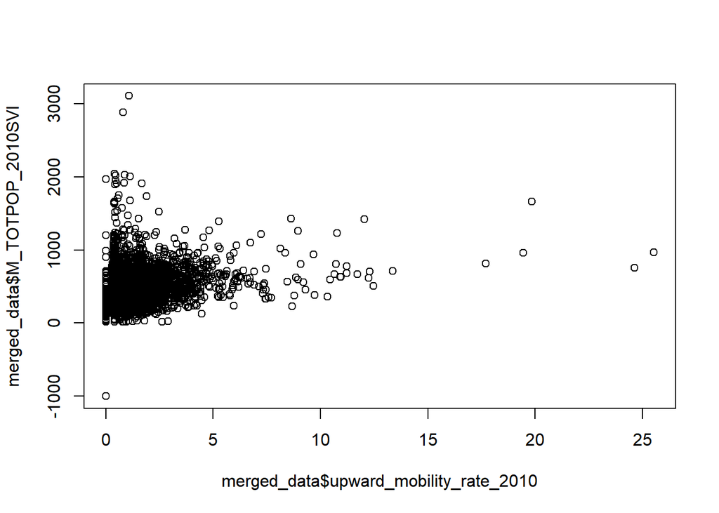

```r
plot(x = merged_data$upward_mobility_rate_2010, y = merged_data$M_TOTPOP_2010SVI)
```

This helps you see the pattern between population and mobility.

This doesn’t look like a straight-line relationship, and we like straight-line (linear) relationships because they’re easier to work with.

To fix this, we’ll apply something called a log transformation to the population data.

That just means we’ll create a new column where we take the log of the population values.

Why do we do this?

- It helps fix data that’s really skewed or stretched out.
- It squishes really big numbers down, making the data easier to compare.
- When we look at charts like histograms, it can make the shape more balanced.
- This makes the data behave more “normally,” which helps us do better and more accurate analysis.

Then we’ll make a new plot using the log-transformed data and see if the relationship looks more like a straight line.

```r
merged$logpop <- log10(merged$M_TOTPOP_2010SVI)
```

And plot again:

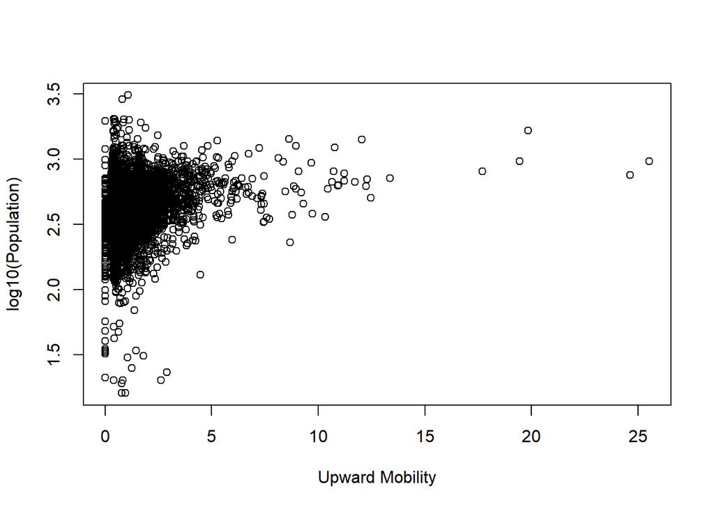

```r
plot(x = merged$upward_mobility_rate_2010,
     y = merged$logpop,
     xlab = "Upward Mobility",
     ylab = "log10(Population)")
```

We added two extra settings to the `plot` command called **xlab** and **ylab**.

These are just used to label the x-axis and y-axis in the chart so it’s easier to understand what the graph is showing.

You can also try making the plot without these labels to see what it looks like—it still works, but the axes won’t be clearly labeled.

Now we’re going to run something called a regression.

A regression is a way to look at the relationship between two variables in your data.

It helps us figure out:

- Is there a connection between them?
- Is that connection strong or weak?
- Is it likely just random, or is it statistically meaningful?

We’re just doing a simple regression here based on the plot we made earlier.

But regression can get much more detailed, you can include more variables, control for things, and dive deeper.

This is just a very basic intro. There are whole courses dedicated to different types of regression!

Run the linear model:

```r
mobility_v_pop <- lm(upward_mobility_rate_2010 ~ logpop, data = merged)

# let’s look at the results:
summary(mobility_v_pop)
```

```
##
## Call:
## lm(formula = upward_mobility_rate_2010 ~ logpop, data = merged)
##
## Residuals:
##     Min      1Q  Median      3Q     Max
## -1.6162 -0.5321 -0.3121  0.1615 24.2319
##
## Coefficients:
##             Estimate Std. Error t value Pr(>|t|)
## (Intercept) -1.81485    0.15953  -11.38   <2e-16 ***
## logpop       1.04174    0.06084   17.12   <2e-16 ***
## ---
## Signif. codes:  0 '***' 0.001 '**' 0.01 '*' 0.05 '.' 0.1 ' ' 1
##
## Residual standard error: 1.091 on 9542 degrees of freedom
##   (54 observations deleted due to missingness)
## Multiple R-squared:  0.02981,    Adjusted R-squared:  0.02971
## F-statistic: 293.2 on 1 and 9542 DF,  p-value: < 2.2e-16
```

The `lm()` function in R fits a linear regression model.

It helps you understand how a response variable (like upward mobility) changes based on one or more predictors (like population).

`logpop`= population size.

Understand the output:

**`Estimate`**: How much mobility increases when log population increases

**`Std. Error`**: How uncertain the estimate is **`t value`** Like the t-test again, this is a statistic

**`Pr(>|t|)`**: if it’s small, that means it’s statistically significant

**Multiple R-squared** How well the model explains the data (0 to 1)

Now focus on the coefficients part of the output, especially the line labeled logpop (that’s the population data we log-transformed earlier).

Here’s what we see:

- The coefficient is 1.042 → This tells us how much upward mobility changes when population increases.
- The standard error is 0.061 → This tells us how precise our estimate is (smaller = better).
- The p-value (shown as Pr(>|t|)) is very small, which is good! → It means the result is statistically significant, or not likely due to random chance.
- There are also stars next to the number—these show that the result is strongly significant.

If we want to instead save the results to a file instead of printing them, we use the sink function.

```r
sink(file = "output/mobility-pop-regression.txt")
summary(mobility_v_pop)
sink()
```

### Multivarite Regression: Let’s add state

Now we’re going to add another variable to our analysis.

Let’s say we want to compare Arizona with California to see if upward mobility is different between the two.

To do that, we’ll create something called a dummy variable.

A dummy variable is just a simple way to say “yes” or “no” in the data.

In this case:

If a row is from Arizona, the dummy variable will be 1

If it’s from California (or anywhere else), it will be 0

This helps us include categorical information (like the state) in our regression model.

Then we can see if just being in Arizona, for example, is linked to higher or lower mobility compared to California.

```r
merged$az <- ifelse(merged$STATE_NAME_2010SVI == "Arizona", 1, 0)
merged$ca <- ifelse(merged$STATE_NAME_2010SVI == "California", 1, 0)
```

Add AZ as a predictor and run the new model:

```r
mobility_v_pop_state <- lm(formula = upward_mobility_rate_2010 ~ logpop + az
                     , data = merged)
summary(mobility_v_pop_state)
```

```
##
## Call:
## lm(formula = upward_mobility_rate_2010 ~ logpop + az, data = merged)
##
## Residuals:
##     Min      1Q  Median      3Q     Max
## -1.6083 -0.5295 -0.3124  0.1648 24.2389
##
## Coefficients:
##             Estimate Std. Error t value Pr(>|t|)
## (Intercept) -1.81273    0.15954 -11.362   <2e-16 ***
## logpop       1.03868    0.06089  17.058   <2e-16 ***
## az           0.03684    0.03054   1.206    0.228
## ---
## Signif. codes:  0 '***' 0.001 '**' 0.01 '*' 0.05 '.' 0.1 ' ' 1
##
## Residual standard error: 1.091 on 9541 degrees of freedom
##   (54 observations deleted due to missingness)
## Multiple R-squared:  0.02996,    Adjusted R-squared:  0.02975
## F-statistic: 147.3 on 2 and 9541 DF,  p-value: < 2.2e-16
```

`az`= whether the location is in Arizona.

If `az` has a small p-value, that means state does matter. If `az` has a large p-value, state does not make a big difference.

Let’s take a look at what the results are showing us now.

First, the relationship between population and mobility is basically the same as before—so adding the new variable didn’t change that.

Now let’s talk about the Arizona dummy variable we added.

The result for Arizona is not statistically significant.

That means we don’t see a clear difference in upward mobility between Arizona and California based on this data.

But that doesn’t mean the state doesn’t matter at all—it just means that, in this case, Arizona isn’t different from California in a way that stands out statistically.

Also, keep in mind:

- California is the baseline or “excluded” group in this comparison
- So the model compares other states (like Arizona) to California.

So, let’s save it

```r
sink(file = "output/mobility-pop-state-regression.txt")
summary(mobility_v_pop)
sink()
```

# Review of Learning Objectives

✅ Reminders about reading data from files and output results to filestreamline workflow using R Projects and Git.

✅ Run standard statistical tests: - Student’s t - ANOVA - Simple linear regression

✅ Gain literacy with piping (`%>%`) and tidy tools.

## Student Activities

Follow these tasks using the skills from Lesson 3.

### 1. Variable exploration

Remember?:

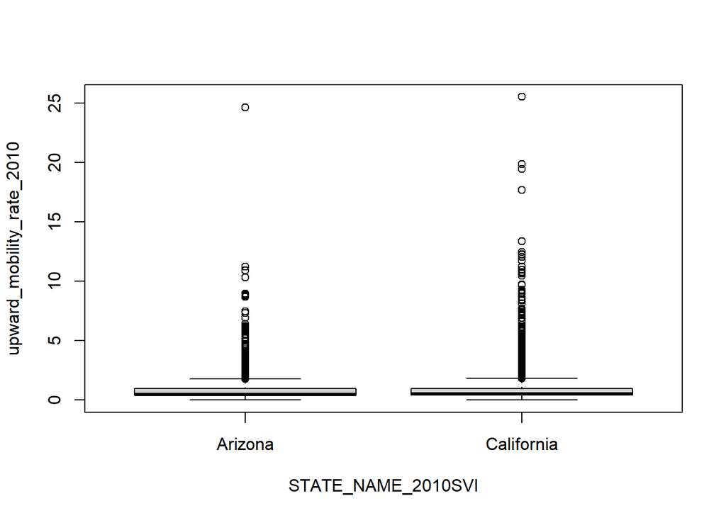

```r
boxplot(formula = upward_mobility_rate_2010 ~ STATE_NAME_2010SVI, data = merged_data)
```

or

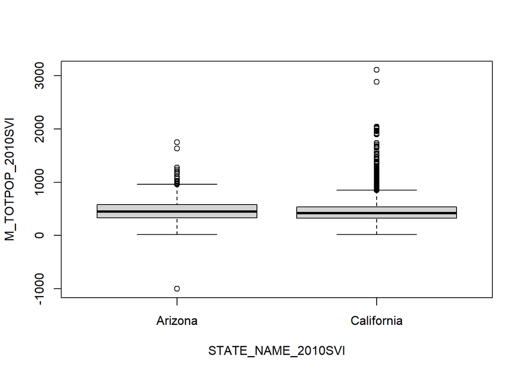

```r
boxplot(formula = M_TOTPOP_2010SVI ~ STATE_NAME_2010SVI, data = merged_data)
```

Pick a variable that you’re curious about, and make a box plot to explore it.

Now think about it:

1. What does this graph show you?
2. why did you choose that variable to explore more?

### 2. Anova analysis

- Use a different variable in Arizona.
- Keep the same variable (`COUNTY_2010SVI`) but look at California instead.

What did you find?

Did the variable you picked have a statistically significant effect?

### 3. Another regression.

Instead of using the original mobility data, let’s switch it up and use mobility data from 2020. You can add more variables into the regression by using the + sign.

Based on today’s learning objectives and everything we explored:

### 4. Reflect and Extend

Where do you feel like you need more…

- Time to practice or explore?
- Energy or support to feel more confident?
- Information or explanation to fully understand?
- What questions do you still have?